# Olympic Games

Sayra Moore, Andrea Piolini, Sabina Shahbazzade, Caroline Sklaver, Spencer Staub

10/13/2019

Olympic Games

# 1 Introduction

Several Kaggle users have conducted various analyses on this dataset using Python and R. Some of these analyses specifically focused on single events, other focused on the analysis of specific sports and some others focused on the variation of age, gender, height and weight over time.

We chose this dataset because of our passion for sports and our shared excitement every time the Olympic Games take place. Therefore, we thought we could use our statistical and R expertise to learn more about these events.

When we looked at the dataset, we thought it would be very interesting to test whether certain characteristics such as height and age have an effect on whether an athlete earns a medal. We also decided to focus on this question because the majority of the analyses on the dataset focus more on descriptive statistic and data visualization, and they do not perform statistical tests to see whether the variables are related and correlated.

```
## 'data.frame':    271116 obs. of  15 variables:
##  $ ID    : int  1 2 3 4 5 5 5 5 5 5 ...
##  $ Name  : Factor w/ 134732 levels "  Gabrielle Marie \"Gabby\" Adcock (White-)",..: 8 9 44318 29412 21470 21470 21470 21470 21470 21470 ...
##  $ Sex   : Factor w/ 2 levels "F","M": 2 2 2 2 1 1 1 1 1 1 ...
##  $ Age   : int  24 23 24 34 21 21 25 25 27 27 ...
##  $ Height: int  180 170 NA NA 185 185 185 185 185 185 ...
##  $ Weight: num  80 60 NA NA 82 82 82 82 82 82 ...
##  $ Team  : Factor w/ 1184 levels "30. Februar",..: 199 199 273 278 705 705 705 705 705 705 ...
##  $ NOC   : Factor w/ 230 levels "AFG","AHO","ALB",..: 42 42 56 56 146 146 146 146 146 146 ...
##  $ Games : Factor w/ 51 levels "1896 Summer",..: 38 49 7 2 37 37 39 39 40 40 ...
##  $ Year  : int  1992 2012 1920 1900 1988 1988 1992 1992 1994 1994 ...
##  $ Season: Factor w/ 2 levels "Summer","Winter": 1 1 1 1 2 2 2 2 2 2 ...
##  $ City  : Factor w/ 42 levels "Albertville",..: 6 18 3 27 9 9 1 1 17 17 ...
##  $ Sport : Factor w/ 66 levels "Aeronautics",..: 9 33 25 62 54 54 54 54 54 54 ...
##  $ Event : Factor w/ 765 levels "Aeronautics Mixed Aeronautics",..: 160 398 349 710 623 619 623 619 623 619 ...
##  $ Medal : Factor w/ 3 levels "Bronze","Gold",..: NA NA NA 2 NA NA NA NA NA NA ...
```

## 1.1 Limitations of the Dataset

There are four limitations in our dataset:

1. The dataset is not complete. There are many NAs for Age, Height, Weight.
2. It does not contain the country hosting the event, it has only the city of event.
3. More information on the country hosting the event and on the ethnicity of the athletes would be beneficial
4. Women did not begin participating until the 1900 Paris Olympics

# 2 Descriptive Statistics

For descriptive statistics we have the following questions for our dataset:

How many athletes participated over the years? How many males? How many females? How many medals were won by country? How many medals were won by males and females? Is there correlation between age, weight, and height? Do these have an effect on winning or not? Is there difference in average age between males and females? Does their average vary over years?

## 2.1 Medals

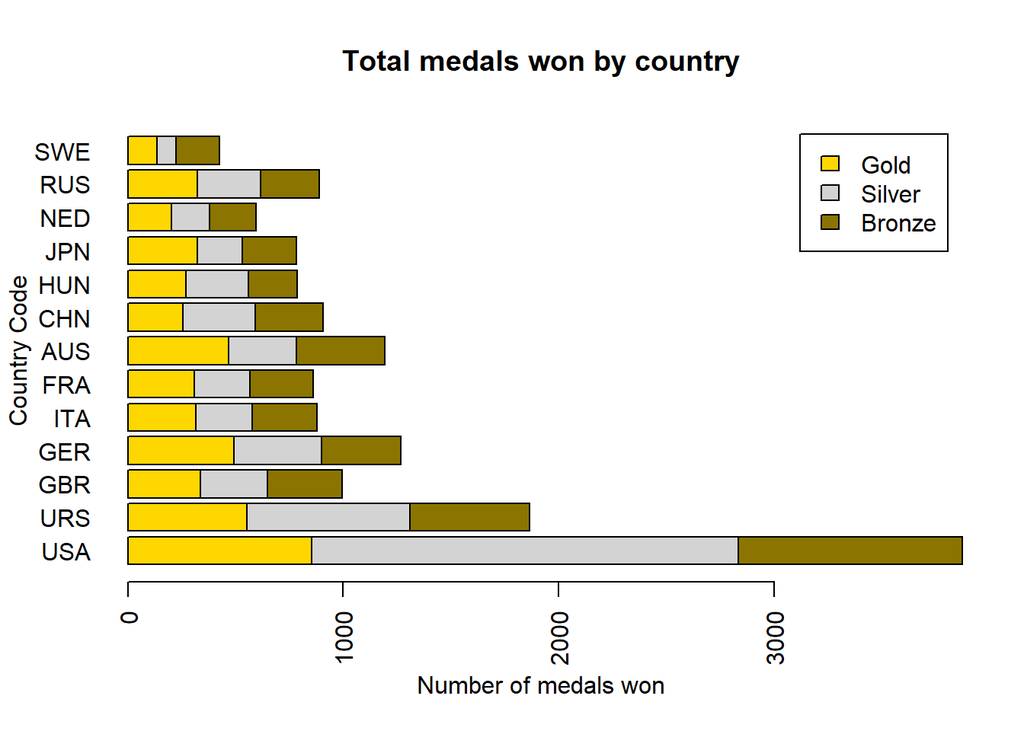

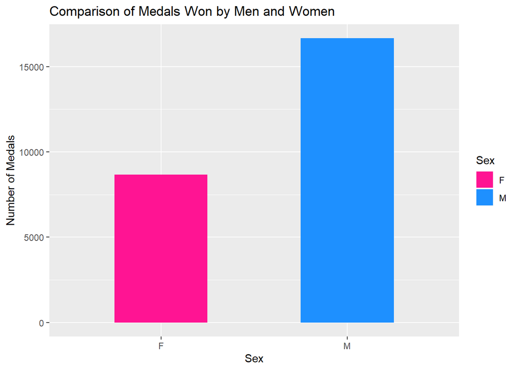

It is also clear that men won more medals than women, where number of medals won by men more than 15,000 and women less than 10,000. One reason of less medals won by women was that women did not participated Olympic games before 1900.

## 2.2 Athletes Participation Over 120 Years of Summer Olympic Games

Graphical representation of number of athletes over the 120 years of Olympics. Additionally, graph of male and female athlete participation over time to visualize the difference in participation by gender.

### 2.2.1 Participation by Year

[figure not shown]

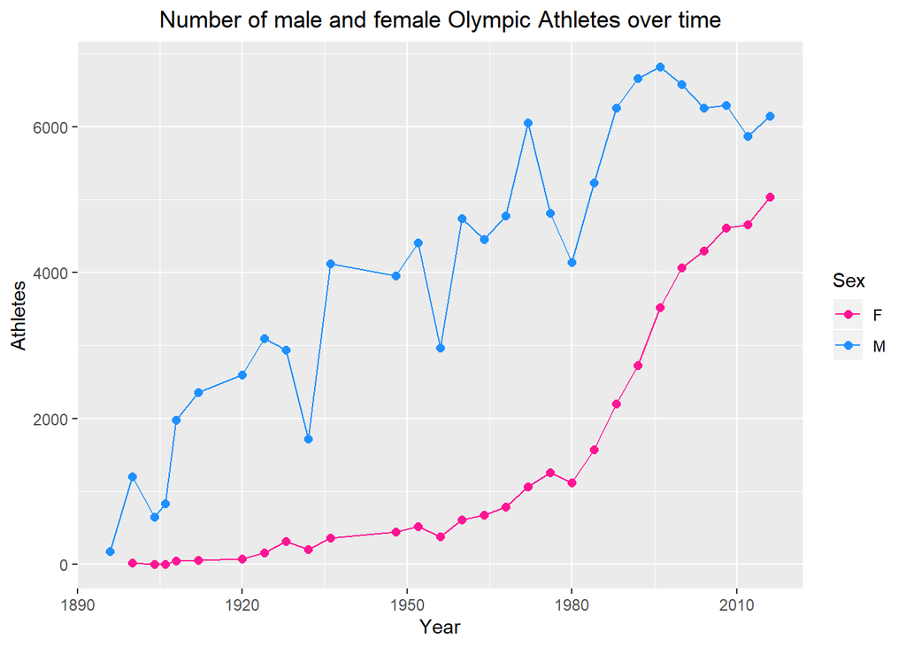

In our participation by year graphs we can see a general increase in participation from the inception of the Olympic games, however, there are a few points where participation decreased. We have hypothesized that these decreases in participation are largely due to wars that encompass a significant amount of the world (ie. World War 1, World War 2, Korean War). We can see that drops in population have affected men a significant amount more than females, which backs up our hypothesis.

### 2.2.2 Participation by Sport

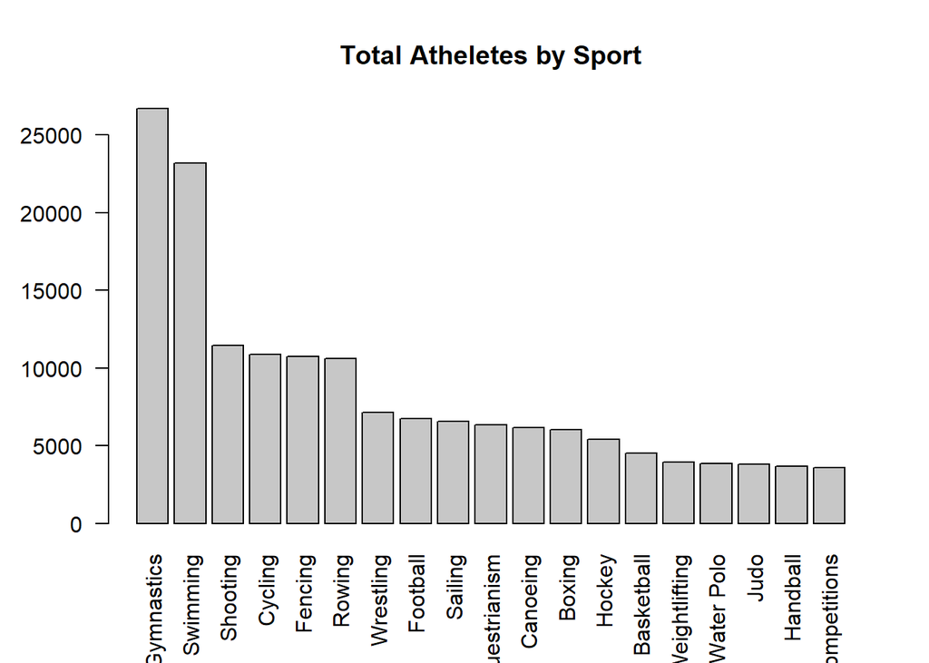

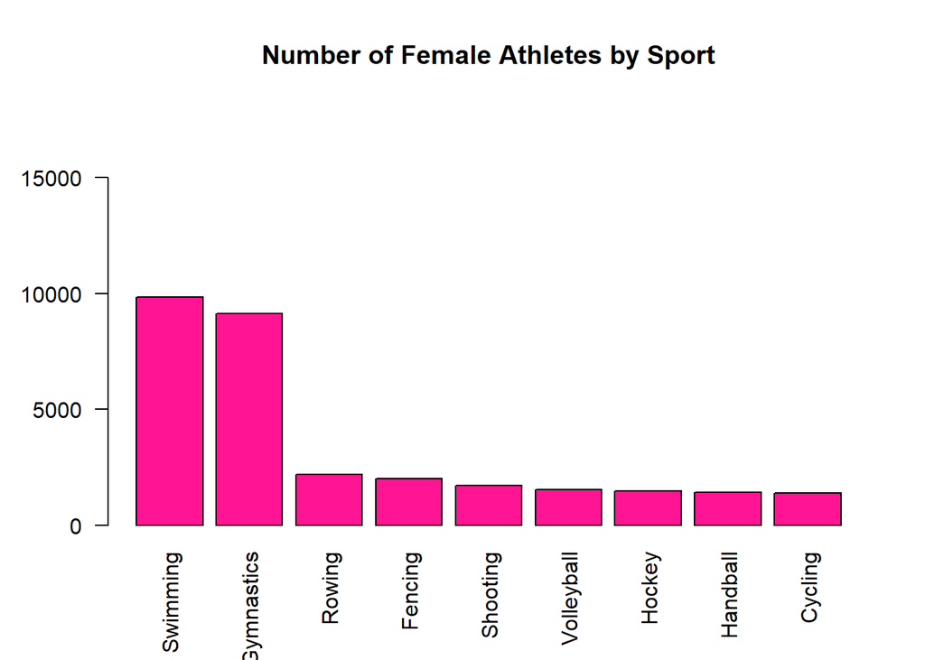

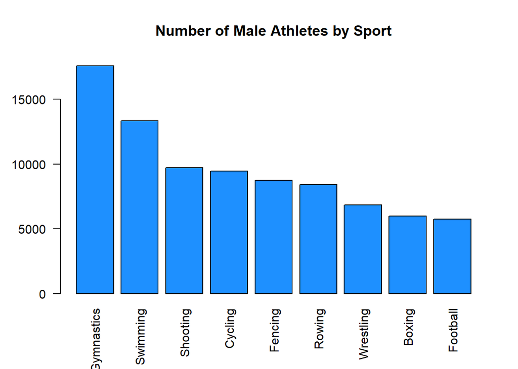

We can also conclude from our participation distribution by sports graphs that gymnastics and swimming are by far the most popular sports of the Olympics, however, for females the two aforementioned sports categories make up a predominant amount of participation. For Males gymnastics and swimming are still quite popular, but the distribution of participation is significantly more even than their female counterparts.

## 2.3 Age, Height, Weight

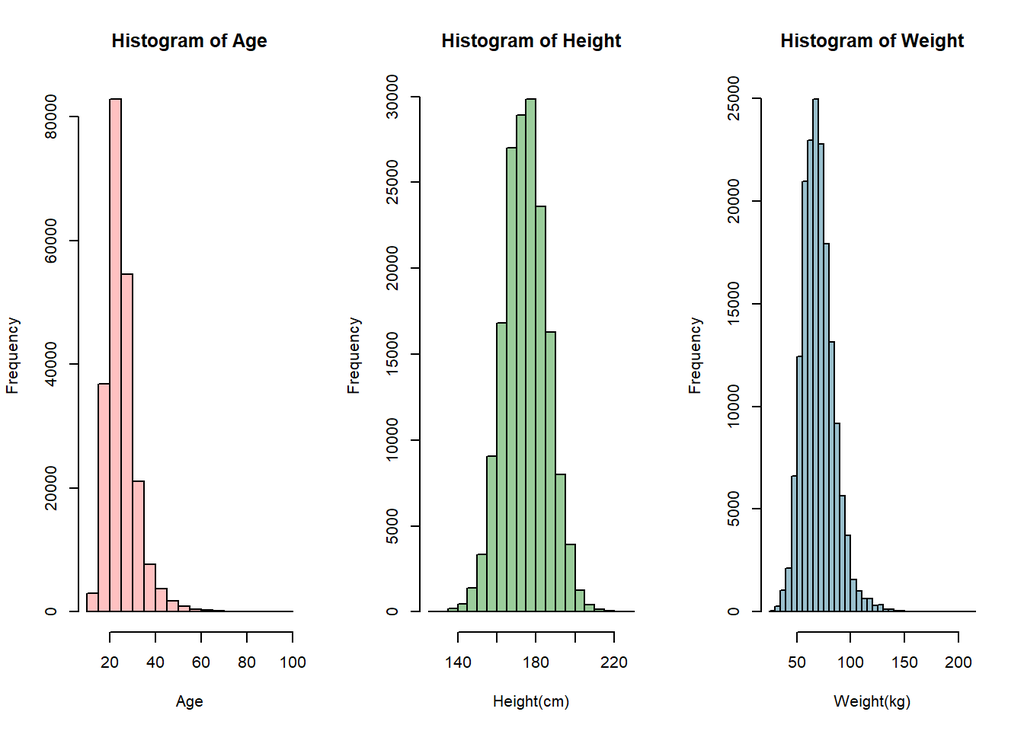

Histograms to view the distribution of Age, Height, and Weight for all Olympic Athletes. This is useful to determine the distribution. Age and weight are a bit right-skewed, height is very normal. These distributions do not vary greatly when looking at males and females separately.

```
##              Age    Height    Weight
## Age    1.0000000 0.1394187 0.2110977
## Height 0.1394187 1.0000000 0.7951830
## Weight 0.2110977 0.7951830 1.0000000
```

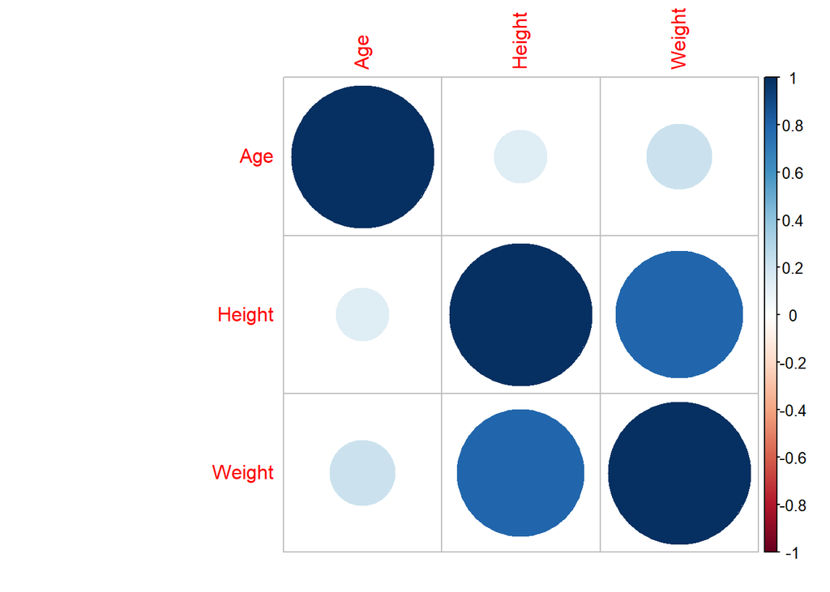

Correlations between age, height, and weight, also represented in graphics. Height and weight are highly correlated (0.7951830).

# 3 Statistical Tests

Our inspiration for the following tests revolved around questions regarding medals won and participant statistics (age, height, weight), as well as participant statistics over time.

## 3.1 Does age, height, or weight determine outcome (winning of medals)?

Chi-squared tests in which the null hypothesis is that age, height, and weight do not have a significant effect on whether athletes won a medal or not.These tests resulted in p-values <0.05 meaning we can reject the null hypotheses and conclude that age, height, and weight all determine whether athletes win medals. The age, height, and weight data was made categorical into intervals based on quartiles and mean of each variable.

```
##    Min. 1st Qu.  Median    Mean 3rd Qu.    Max.    NA's
##   10.00   21.00   24.00   25.67   28.00   97.00    9189
```

```
##    Min. 1st Qu.  Median    Mean 3rd Qu.    Max.    NA's
##   127.0   168.0   175.0   175.5   183.0   226.0   51857
```

```
##    Min. 1st Qu.  Median    Mean 3rd Qu.    Max.    NA's
##   25.00   60.00   70.00   70.69   79.00  214.00   53854
```

```
##
##  Pearson's Chi-squared test
##
## data:  cont_age_medal_w_na
## X-squared = 407.17, df = 2, p-value < 2.2e-16
```

```
##
##  Pearson's Chi-squared test
##
## data:  cont_height_medal_w_na
## X-squared = 1261.9, df = 2, p-value < 2.2e-16
```

```
##
##  Pearson's Chi-squared test
##
## data:  cont_weight_medal_w_na
## X-squared = 1259.2, df = 2, p-value < 2.2e-16
```

## 3.2 Does the average age vary between men and women?

Performed a 2-sample t-test to determine whether the mean age of men significantly differs from that of women. Null hypothesis is that the two means do not differ. With p-value < 0.05, we reject the null hypothesis and conclude that the average age of men and women significantly differs in summer Olympic athletes.

```
## [1] 25.70011
```

```
## [1] 23.6531
```

```
##
##  Welch Two Sample t-test
##
## data:  m$Age and f$Age
## t = 68.802, df = 100787, p-value < 2.2e-16
## alternative hypothesis: true difference in means is not equal to 0
## 95 percent confidence interval:
##  1.988699 2.105327
## sample estimates:
## mean of x mean of y
##  25.70011  23.65310
```

## 3.3 Does age, height, and weight significantly change over the years?

### 3.3.1 Height

```
##                 Df   Sum Sq Mean Sq F value Pr(>F)
## Year            28   452163   16149   171.7 <2e-16 ***
## Residuals   113296 10658736      94
## ---
## Signif. codes:  0 '***' 0.001 '**' 0.01 '*' 0.05 '.' 0.1 ' ' 1
```

```
##                Df  Sum Sq Mean Sq F value Pr(>F)
## Year           22  157060    7139   85.42 <2e-16 ***
## Residuals   53358 4459645      84
## ---
## Signif. codes:  0 '***' 0.001 '**' 0.01 '*' 0.05 '.' 0.1 ' ' 1
```

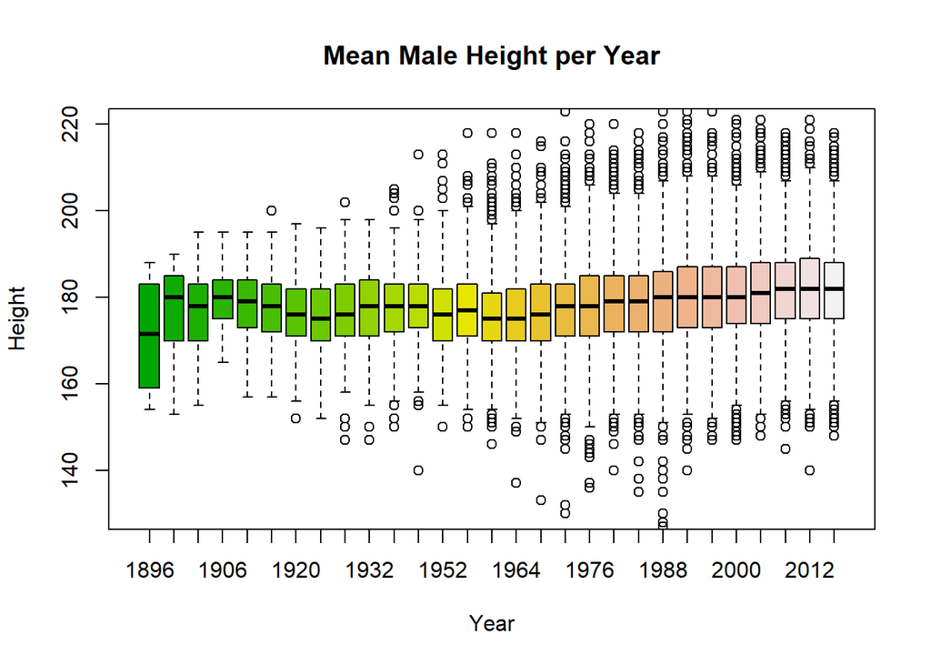

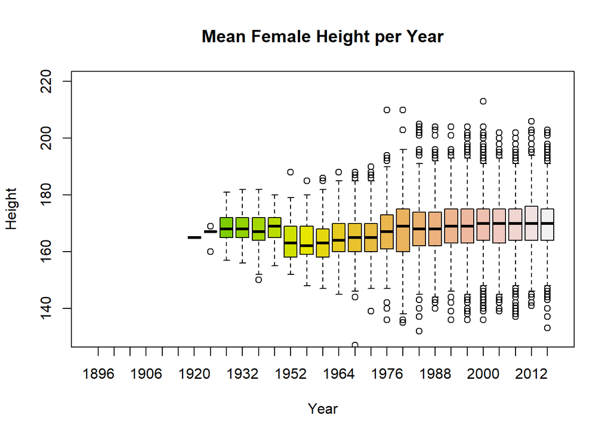

The graphs bellow show a slight increase in height over time for male and female. The graphs also show a larger distribution of heights as time moves on. This is likely to be due to an increase in participation as well as an increase in countries and diversity.

### 3.3.2 Age

```
##                 Df  Sum Sq Mean Sq F value Pr(>F)
## Year            28   51483  1838.7    61.5 <2e-16 ***
## Residuals   113296 3387142    29.9
## ---
## Signif. codes:  0 '***' 0.001 '**' 0.01 '*' 0.05 '.' 0.1 ' ' 1
```

```
##                Df  Sum Sq Mean Sq F value Pr(>F)
## Year           22  155311    7060   234.8 <2e-16 ***
## Residuals   53358 1604087      30
## ---
## Signif. codes:  0 '***' 0.001 '**' 0.01 '*' 0.05 '.' 0.1 ' ' 1
```

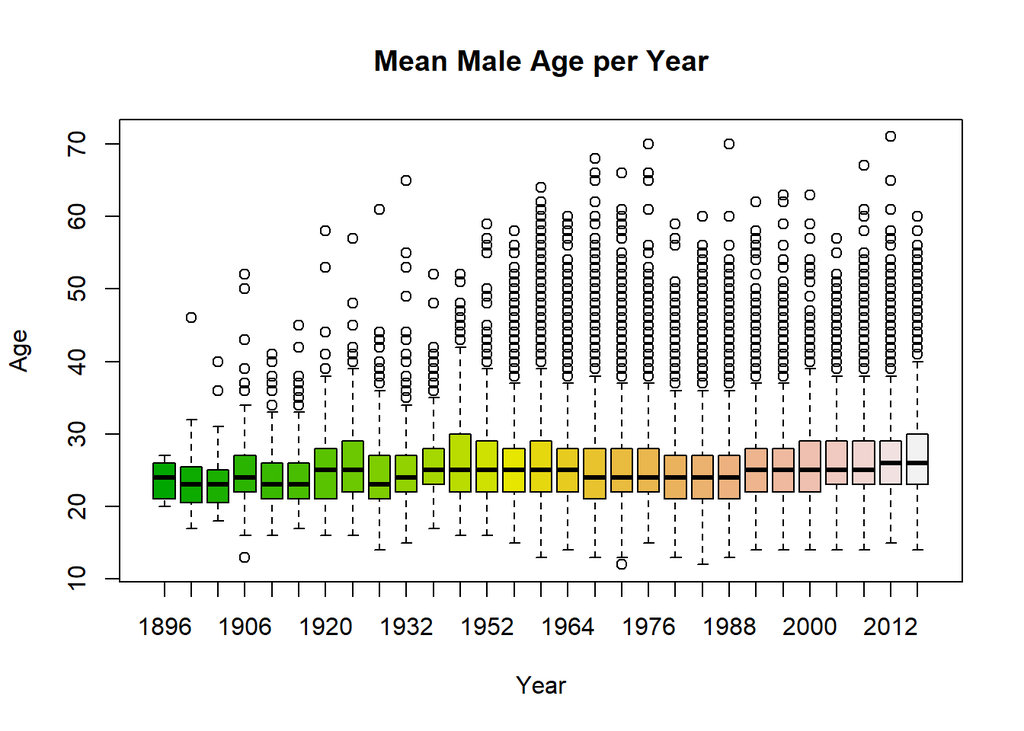

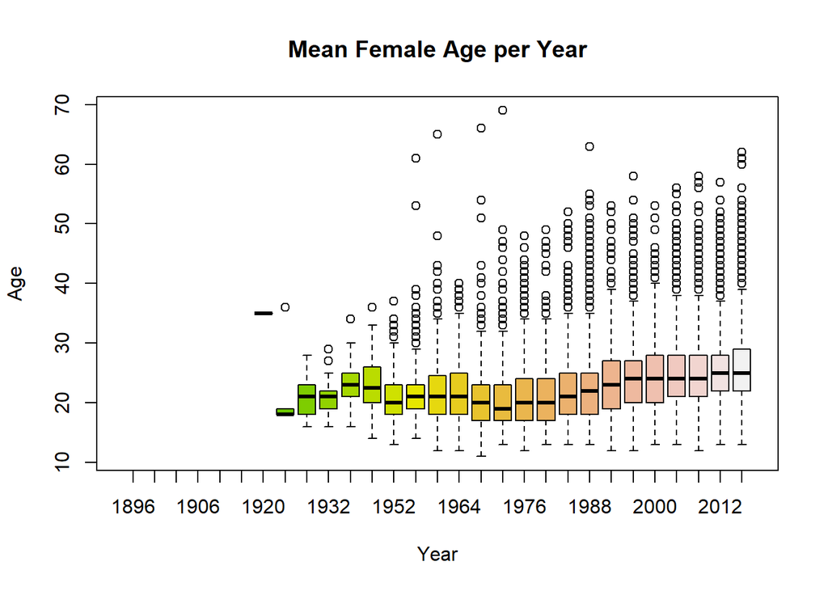

### 3.3.3 Weight

```
##                 Df   Sum Sq Mean Sq F value Pr(>F)
## Year            28   649084   23182   126.3 <2e-16 ***
## Residuals   113296 20792048     184
## ---
## Signif. codes:  0 '***' 0.001 '**' 0.01 '*' 0.05 '.' 0.1 ' ' 1
```

```
##                Df  Sum Sq Mean Sq F value Pr(>F)
## Year           22  156875    7131   62.08 <2e-16 ***
## Residuals   53358 6129093     115
## ---
## Signif. codes:  0 '***' 0.001 '**' 0.01 '*' 0.05 '.' 0.1 ' ' 1
```

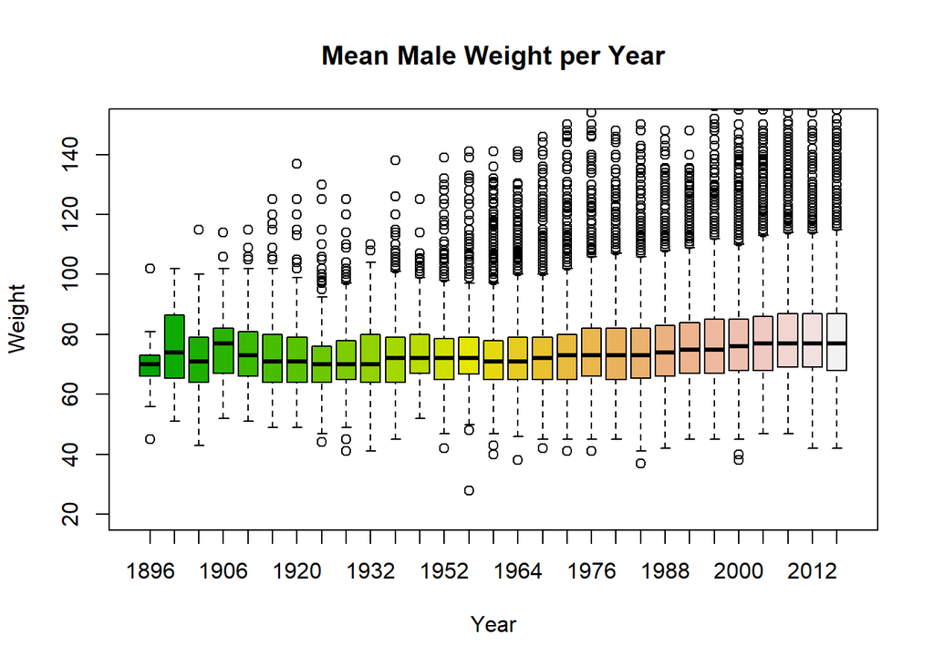

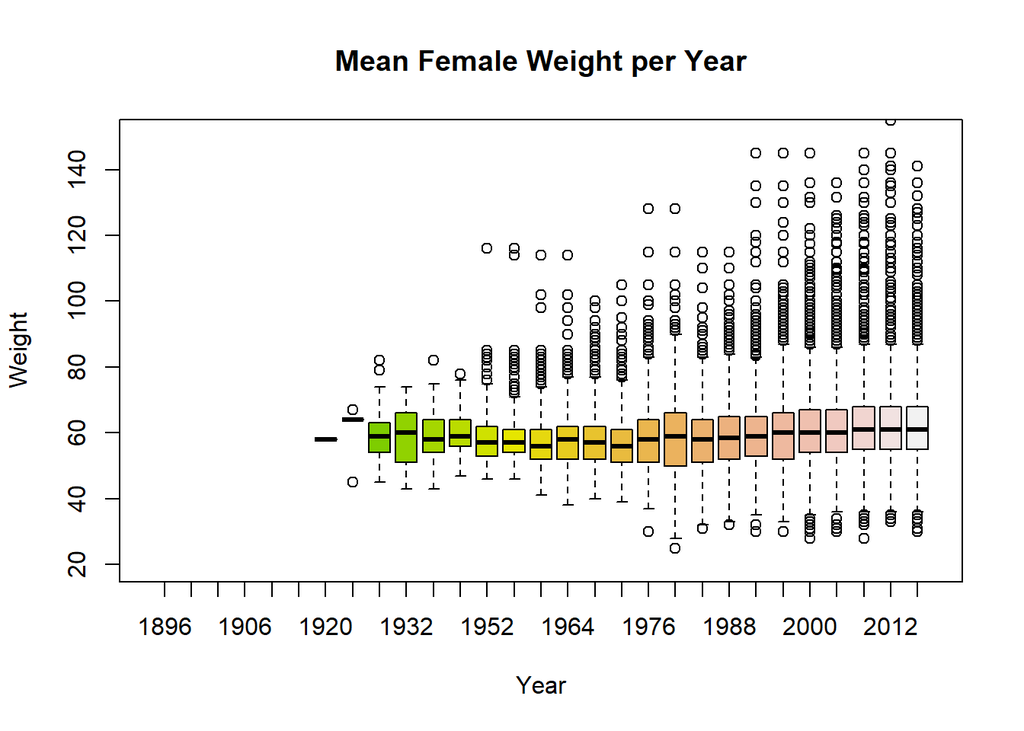

In the graphs above we can see that weight has stayed relatively constant for both male and females for all Olympic games, although there may be a slight increase over time. Like every other statistics the distribution gets larger as time move forward.

# 4 Conclusion

## 4.1 Additional Information

The dataset also contains the name of the cities that hosted the events; however, it does not have the name of the countries that hosted them. In our opinion, having the names of the hosting countries would have been beneficial because we could have seen what are the countries that hosted the largest number of events over time, and we could have also tested whether the athletes competing at the events hosted by their own country have an advantage over the other athletes. We envision that further analysis would include additional datasets that link city to country.

## 4.2 Chapter 5.2: Question Changes?

Most of our SMART questions did not change after the exploratory data analysis as we had all the data we needed to find an answer them. However, our EDA did bring about new SMART questions which would be worth exploring more in depth. For example, by conducting Chi Square tests we found out that age, weight and eight do have an effect on whether an athlete earns a medal, but we did not analyze in what way those variables have an effect on the outcome and if there are some specific sports where these variables matters the most. Therefore, from the initial EDA we got new questions that could and should be answered through another EDA of the dataset.

## 4.4 Future Direction

Moving forward we believe a more in-depth EDA and more correlative SMART questions are possible. As mentioned previously we would like to explore how age, height and weight affect the medal awarded. That is how do each of these statistics correlate to the type of medal won. We would also break this analysis down by competition since weight and height play different rolls in their respective sports. In addition to this medal distribution as affected by athlete statistics we could also investigate how the hosting country affects the medal distribution by country. Does the host win more medals than they normally do when in a non-hosting year? Also how does hosting the Olympics affect the host countries performance in subsequent Olympic games.

# 5 Bibliography

Griffin, R. (2019). 120 years of Olympic history: athletes and results. [online] Kaggle.com. Available at: https://www.kaggle.com/heesoo37/120-years-of-olympic-history-athletes-and-results [Accessed May 2018].